# G920_Lab5_Fastovich

David Fastovich

October 5, 2018

```
## ### Welcome to rworldmap ###
```

```
## For a short introduction type :   vignette('rworldmap')
```

#### Question 1

`http://api.neotomadb.org/v1/data/sites?sitename=*tulane*`

Returns:

`{ success: 1, data: [ { LongitudeWest: -81.50634, SiteID: 2570, SiteName: "Lake Tulane", Altitude: 32, LongitudeEast: -81.50045, SiteDescription: "Sinkhole lake on the Lake Wales Ridge. Native vegetation was Florida srcub with Pinus elliotti and Pinus clausa, but lake is now in the town of Avon Park. Lake has two basins, north and south.", LatitudeNorth: 27.58973, LatitudeSouth: 27.58253 } ] }`

`http://api.neotomadb.org/v1/data/sites?sitename=*spicer*`

Returns:

`{ success: 1, data: [ { LongitudeWest: -86.52289, SiteID: 13350, SiteName: "Spicer Lake", Altitude: 242, LongitudeEast: -86.52127, SiteDescription: "Spicer Lake is located in New Carlisle, St. Joseph County, northern Indiana. It is a kettle lake formed by stagnant ice embedded in the glacial till left behind when the Lake Michigan Lobe of the Laurentide Ice Sheet retreated into Indiana ca. 15,000 years ago. Much of the kettle has filled in, leaving 5 ha of open water, surrounded by swamp and wetland forests.", LatitudeNorth: 41.75809, LatitudeSouth: 41.75667 } ] }`

#### Question 2

`http://api.neotomadb.org/v1/data/datasets?siteid=2570`

Returns:

`{ success: 1, data: [ { DatabaseName: "North American Pollen Database", DOI: null, AgeOldest: null, CollUnitName: null, CollUnitHandle: "TULANE", Site: { LongitudeWest: -81.50634, SiteID: 2570, SiteName: "Lake Tulane", Altitude: 32, LongitudeEast: -81.50045, SiteDescription: "Sinkhole lake on the Lake Wales Ridge. Native vegetation was Florida srcub with Pinus elliotti and Pinus clausa, but lake is now in the town of Avon Park. Lake has two basins, north and south.", LatitudeNorth: 27.58973, LatitudeSouth: 27.58253, SiteNotes: null },` Output continues, but for the sake of readability I only included the first set of values returned from the API call.

`http://api.neotomadb.org/v1/data/downloads/2865`

Returns:

`{ success: 1, data: [ { CollUnitType: "Modern", DatasetName: null, DatabaseName: "North American Pollen Database", Samples: [ { SampleName: null, AnalysisUnitDepth: 0, AnalysisUnitName: null, SampleID: 54312, SampleData: [ { TaxonName: "Unknown", VariableUnits: "NISP", VariableElement: "pollen/spore", VariableContext: null, TaxaGroup: "Unidentified palynomorphs", Value: 3, EcolGroupID: "UNID" },` Output continues, but for the sake of readability I only included the first set of values returned from the API call.

#### Question 3

`http://api.neotomadb.org/v1/dbtables/Geochronology?limit=50&offset=0`

Returns: `{ success: 1, data: [ { MaterialDated: "peat", Age: 3540, SampleID: 108001, GeochronID: 1, RecDateModified: "2014-02-28T04:51:49", LabNumber: "WAT-2088", ErrorOlder: 70, AgeTypeID: 4, Delta13C: null, ErrorYounger: 70, GeochronTypeID: 2, Notes: null, Infinite: false, RecDateCreated: "2013-09-30T14:02:50" },`

Output continues, but for the sake of readability I only included the first set of values returned from the API call.

#### Question 4

```r
clear <- get_site(sitename = "%clear%")
```

```
## The API call was successful, you have returned  48 records.
```

48 sites have the name **clear** in them.

#### Question 5

```r
WI.sites <- get_site(gpid = "Wisconsin")
```

```
## The API call was successful, you have returned  459 records.
```

```r
MN.sites <- get_site(gpid = "Minnesota")
```

```
## The API call was successful, you have returned  518 records.
```

Minnesota (518 records) has more records than Wisconsin (459 records).

#### Question 6

```r
devil.sites <- get_site("Devil%")
```

```
## The API call was successful, you have returned  17 records.
```

```r
devil.sites # Looks like the Devil's Lake we're interested in is the second one
```

```
##                        site.name       long      lat elev
##  Devils Lake, Main Bay            -98.95059 48.03154  443
##  Devils Lake                      -89.73205 43.41780  294
##  Devil's Mouth [41VV188]         -101.00000 29.36667   NA
##  Devil's Hollow [41TV38]          -97.75000 30.36667   NA
##  Devil's Den                      -82.36667 29.36667   24
##  Devil's Eye Spring               -82.75000 29.86667   10
##  Devil's Staircase Pit Cave       -86.25000 38.11667   NA
##  Devil's Walking Stick [9Cam177]  -81.50000 30.75000   NA
##  Devils Lake, Creel Bay           -98.92935 48.08590  443
##  Devils Lake, Mission Bay         -98.88682 48.01823  443
##  Devils Lake                      -98.91884 48.05036  443
##  Devil's Bathtub                  -77.57376 43.02469  198
##  Devils Lake                      -93.33381 45.81509   NA
##  Devil's Lake                    -123.99247 44.98338    3
##  Devil's Canopy Cave [AKPET221]  -133.50000 56.16667  180
##  Devils Lake                      -98.89294 48.01890  434
##  Devil Peak Fauna                -115.45222 35.69722 3600
## A site object containing 17 sites and 8 parameters.
```

```r
devil.sites$site.id[2]
```

```
## [1] 666
```

```r
devil.data <- get_dataset(devil.sites$site.id[2])
```

```
## The API call was successful, you have returned 5 records.
```

```r
devil.data
```

```
## A dataset_list containing 5 objects:
## Accessed from 2018-10-12 10:26h to 2018-10-12 10:26h.
## Datasets:
##  dataset.id   site.name      long     lat                     type
##         684 Devils Lake -89.73205 43.4178 pollen
##        3802 Devils Lake -89.73205 43.4178 pollen surface sample
##        8060 Devils Lake -89.73205 43.4178 geochronologic
##       14858 Devils Lake -89.73205 43.4178 water chemistry
##       14859 Devils Lake -89.73205 43.4178 ostracode surface sample
```

There are five datasets for Devil’s Lake

#### Question 7

```r
tul.site <- get_site("*tulane*")
```

```
## The API call was successful, you have returned  1 records.
```

```r
tul.dataset <- get_dataset(tul.site, datasettype = "pollen")
tul.down <- get_download(tul.dataset)
```

```
## API call was successful. Returned record for Lake Tulane
## API call was successful. Returned record for Lake Tulane
```

```r
tul.poll <- tul.down$`19620`$counts
tul.p25 <- compile_taxa(tul.poll, list.name = "P25")
```

[output not shown]

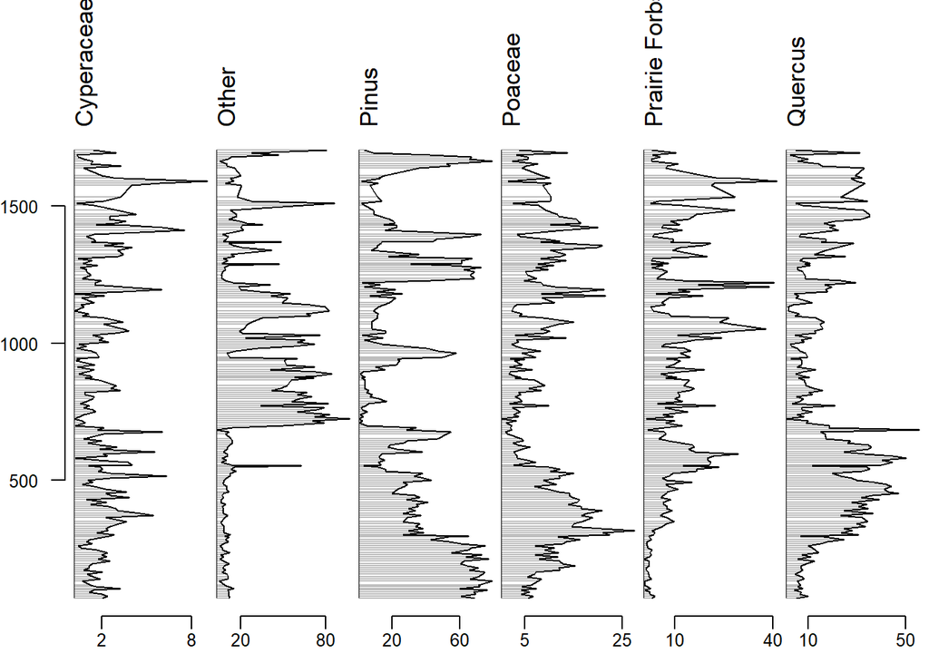

```r
tul.p25.perc <- (tul.p25/rowSums(tul.p25))*100
tul.p25.perc <- tul.p25.perc[, colMeans(tul.p25.perc) > 2]
strat.plot(d = tul.p25.perc, yvar = tul.down$`19620`$sample.meta$depth)
```

#### Question 8

```r
# Finding all datasets with Picea that fall within the the time window of interest
pic.dec <- get_dataset(taxonname = "Picea*",
                       datasettype = "pollen",
                       loc = c(-98.6, 36.5, -66.1, 49.75),
                       ageyoung = 11000, ageold = 21000)
```

```
## The API call was successful, you have returned 303 records.
```

```r
# Downloading the releveant data
pic.dec.down <- get_download(pic.dec)
```

```
## API call was successful. Returned record for Almora Lake
```

```
## API call was successful. Returned record for Anderson Lake
```

```
## API call was successful. Returned record for Andree Bog
```

```
## API call was successful. Returned record for Lac à l'Ange
```

```
## API call was successful. Returned record for Arrington Marsh
```

```
## API call was successful. Returned record for Lac des Atocas
```

```
## API call was successful. Returned record for Axe Lake
```

```
## API call was successful. Returned record for Barry Lake
```

```
## API call was successful. Returned record for Baseball Bog
```

```
## API call was successful. Returned record for Battaglia Bog
```

```
## API call was successful. Returned record for Bear Bog
```

```
## API call was successful. Returned record for Belmont Bog
```

```
## API call was successful. Returned record for Berry Pond
```

```
## API call was successful. Returned record for Big Pond
```

```
## API call was successful. Returned record for Billy's Lake
```

```
## API call was successful. Returned record for Blackhoof Site
```

```
## API call was successful. Returned record for Blue Mounds Creek
```

```
## API call was successful. Returned record for Bondi Section
```

```
## API call was successful. Returned record for Lac Boucané
```

```
## API call was successful. Returned record for Boundary Pond
```

```
## API call was successful. Returned record for Brandreth Bog
```

```
## API call was successful. Returned record for Brophy Ditch
```

```
## API call was successful. Returned record for Brown Lake
```

```
## API call was successful. Returned record for Browns Pond
```

```
## API call was successful. Returned record for Bucyrus Bog
```

```
## API call was successful. Returned record for Lac à la Busque
```

```
## API call was successful. Returned record for Saint-Calixte
```

```
## API call was successful. Returned record for Camp 11 Lake
```

```
## API call was successful. Returned record for Carter Site
```

```
## API call was successful. Returned record for Lac Castor
```

```
## API call was successful. Returned record for Cedar Bog
```

```
## API call was successful. Returned record for Chippewa Bog
```

```
## API call was successful. Returned record for Chatsworth Bog
```

```
## API call was successful. Returned record for Clear Lake
## API call was successful. Returned record for Clear Lake
```

```
## API call was successful. Returned record for Colo Marsh
```

```
## API call was successful. Returned record for Cranberry Lake
```

```
## API call was successful. Returned record for Cranberry Glades
```

```
## API call was successful. Returned record for Crates Lake
```

```
## API call was successful. Returned record for Creditview Wetland
```

```
## API call was successful. Returned record for Crider's Pond
```

```
## API call was successful. Returned record for Cupola Pond
```

```
## API call was successful. Returned record for Dark Lake
```

```
## API call was successful. Returned record for Decoy Lake
```

```
## API call was successful. Returned record for Deer Lake Bog
```

```
## API call was successful. Returned record for Demont Lake
```

```
## API call was successful. Returned record for Devils Lake
```

```
## API call was successful. Returned record for Lac du Diable
```

```
## API call was successful. Returned record for Dismal Swamp (91)
```

```
## API call was successful. Returned record for Disterhaft Farm Bog
```

```
## API call was successful. Returned record for Duck Pond
```

```
## API call was successful. Returned record for Lac Dufresne
```

```
## API call was successful. Returned record for Eagle Lake Bog
```

```
## API call was successful. Returned record for Edward Lake
```

```
## API call was successful. Returned record for Lake Erie
```

```
## API call was successful. Returned record for Ernst Brother's Pit
```

```
## API call was successful. Returned record for Lac à la Fourche
```

```
## API call was successful. Returned record for East Twin Lake
```

```
## API call was successful. Returned record for Fawn Lake(CA:Ontario)
```

```
## API call was successful. Returned record for Frains Lake
```

```
## API call was successful. Returned record for Hayes Lake
```

```
## API call was successful. Returned record for Fresh Pond
```

```
## API call was successful. Returned record for Fudger Lake
```

```
## API call was successful. Returned record for Gass Lake
```

```
## API call was successful. Returned record for Georgian Bay, LakeHuron (1)
```

```
## API call was successful. Returned record for Georgian Bay, LakeHuron (2)
```

```
## API call was successful. Returned record for Lac Geai
```

```
## API call was successful. Returned record for Lac à St-Germain
```

```
## API call was successful. Returned record for Gould Pond
```

```
## API call was successful. Returned record for Gould's Bog
```

```
## API call was successful. Returned record for Graham Lake
```

```
## API call was successful. Returned record for Green Lake
```

```
## API call was successful. Returned record for Hack Pond
```

```
## API call was successful. Returned record for Hams Lake
```

```
## API call was successful. Returned record for Hansen Marsh
```

```
## API call was successful. Returned record for Hawley Bog Pond-1
```

```
## API call was successful. Returned record for Helmetta Bog
```

```
## API call was successful. Returned record for High Lake
```

```
## API call was successful. Returned record for Horseshoe Lake
```

```
## API call was successful. Returned record for Houghton Bog
```

```
## API call was successful. Returned record for Hudson Lake
```

```
## API call was successful. Returned record for Inglesby Lake
```

```
## API call was successful. Returned record for Iola Bog
```

```
## API call was successful. Returned record for Irvin Lake
```

```
## API call was successful. Returned record for Jack Lake
```

```
## API call was successful. Returned record for Jackson Pond
```

```
## API call was successful. Returned record for Jacobson Lake
```

```
## API call was successful. Returned record for Saint-Jean Iled'Orléans
```

```
## API call was successful. Returned record for Jewell Site
```

```
## API call was successful. Returned record for Kellys Hollow
```

```
## API call was successful. Returned record for Kellners Lake
```

```
## API call was successful. Returned record for Kinsman Pond
```

```
## API call was successful. Returned record for Kirchner Marsh
```

```
## API call was successful. Returned record for Kitchner Lake
```

```
## API call was successful. Returned record for Kotiranta Lake
```

```
## API call was successful. Returned record for Kylen Lake
```

```
## API call was successful. Returned record for Lac Colin
```

```
## API call was successful. Returned record for Ladd Lake
```

```
## API call was successful. Returned record for Lake Sixteen
```

```
## API call was successful. Returned record for Lake QC
```

```
## API call was successful. Returned record for Lily Lake
```

```
## API call was successful. Returned record for Little Bass Lake
```

```
## API call was successful. Returned record for Little Lake
```

```
## API call was successful. Returned record for Little Pine Lake
```

```
## API call was successful. Returned record for LDDsite5772
```

```
## API call was successful. Returned record for Lake of the Clouds
```

```
## API call was successful. Returned record for Lockport Gulf Section
```

```
## API call was successful. Returned record for Lonesome Lake
```

```
## API call was successful. Returned record for Longswamp
```

```
## API call was successful. Returned record for Loon Pond
```

```
## API call was successful. Returned record for Lost Lake
```

```
## API call was successful. Returned record for Lost Pond
```

```
## API call was successful. Returned record for Tourbière du lacMalbaie
```

```
## API call was successful. Returned record for Maplehurst Lake
```

```
## API call was successful. Returned record for Lac Marcotte
```

```
## API call was successful. Returned record for Wapizagonke
```

```
## API call was successful. Returned record for Sud du Lac du Noyer
```

```
## API call was successful. Returned record for McLaughlan Lake
```

```
## API call was successful. Returned record for Medicine Lake
```

```
## API call was successful. Returned record for Lake Mendota
```

```
## API call was successful. Returned record for Lac Mimi
```

```
## API call was successful. Returned record for Monhegan IslandMeadow
```

```
## API call was successful. Returned record for Moon Lake
```

```
## API call was successful. Returned record for Moulton Pond
```

```
## API call was successful. Returned record for Muscotah Marsh
```

```
## API call was successful. Returned record for Myrtle Lake
```

```
## API call was successful. Returned record for Neville Marsh
```

```
## API call was successful. Returned record for Nichols Brook Site
```

```
## API call was successful. Returned record for Nina Lake
```

```
## API call was successful. Returned record for No Bottom Pond
```

```
## API call was successful. Returned record for North Pond
```

```
## API call was successful. Returned record for Nutt Lake
```

```
## API call was successful. Returned record for West Okoboji Lake
```

```
## API call was successful. Returned record for Oliver Pond
```

```
## API call was successful. Returned record for Lake Ontario,Rochester Basin
```

```
## API call was successful. Returned record for Lake Ontario,Mississauga Basin
```

```
## API call was successful. Returned record for Lac Ouellet
```

```
## API call was successful. Returned record for Panther Run Pond
```

```
## API call was successful. Returned record for Parkhill Creek
```

```
## API call was successful. Returned record for Pass Lake
```

```
## API call was successful. Returned record for Paynter Marsh
```

```
## API call was successful. Returned record for Peatsah Section
```

```
## API call was successful. Returned record for Pilot Mound Site
```

```
## API call was successful. Returned record for Pink Lake
```

```
## API call was successful. Returned record for Poland Spring Pond
```

```
## API call was successful. Returned record for Porqui Pond
```

```
## API call was successful. Returned record for Portage Lake
```

```
## API call was successful. Returned record for Portage Marsh
```

```
## API call was successful. Returned record for Potts Mountain Pond
```

```
## API call was successful. Returned record for Powers Fort Swale
```

```
## API call was successful. Returned record for Princeville
```

```
## API call was successful. Returned record for Protection Bog
```

```
## API call was successful. Returned record for Pyle Site
```

```
## API call was successful. Returned record for Quarles Pond
```

```
## API call was successful. Returned record for Quillin Site
```

```
## API call was successful. Returned record for Radtke Lake
```

```
## API call was successful. Returned record for Ramsay Lake
```

```
## API call was successful. Returned record for Rattle Lake
```

```
## API call was successful. Returned record for Vallée de l'Albion
```

```
## API call was successful. Returned record for Reidel Lake
```

```
## API call was successful. Returned record for Rhule Fen
```

```
## API call was successful. Returned record for Rogers Lake
```

```
## API call was successful. Returned record for Rose Swamp
```

```
## API call was successful. Returned record for Rose Lake
```

```
## API call was successful. Returned record for Rossburg Bog
```

```
## API call was successful. Returned record for Ross Pond
```

```
## API call was successful. Returned record for Rostock Mammoth Site
```

```
## API call was successful. Returned record for Rutz Lake
```

```
## API call was successful. Returned record for Lac Manitou
```

```
## API call was successful. Returned record for Lac aux Quenouilles
```

```
## API call was successful. Returned record for Second Lake
```

```
## API call was successful. Returned record for Seidel
```

```
## API call was successful. Returned record for Seminary Site
```

```
## API call was successful. Returned record for Saint-Francois deSales
```

```
## API call was successful. Returned record for Shady Valley Bog
```

```
## API call was successful. Returned record for Mont Shefford
```

```
## API call was successful. Returned record for Shouldice Lake
```

```
## API call was successful. Returned record for Silver Lake
```

```
## API call was successful. Returned record for Sinkhole Pond
```

```
## API call was successful. Returned record for Smoot Lake Bog
```

```
## API call was successful. Returned record for Spirit Lake
```

```
## API call was successful. Returned record for Spring Lake
```

```
## API call was successful. Returned record for Spruce Pond
```

```
## API call was successful. Returned record for Stone Lake TamarackSwamp
```

```
## API call was successful. Returned record for Stotzel-Leis Site
```

```
## API call was successful. Returned record for Sutherland Pond
```

```
## API call was successful. Returned record for Szabo Pond
```

```
## API call was successful. Returned record for Tannersville Bog
```

```
## API call was successful. Returned record for Williams Street Bog
```

```
## API call was successful. Returned record for Taupawshas Bog
```

```
## API call was successful. Returned record for Petit Lac Terrien
```

```
## API call was successful. Returned record for Titicut Swamp
```

```
## API call was successful. Returned record for Tonawa Lake
```

```
## API call was successful. Returned record for Lac à la Tortue
```

```
## API call was successful. Returned record for Unknown Pond
```

```
## API call was successful. Returned record for Upper Graven Lake
```

```
## API call was successful. Returned record for Upper Mallot Lake
```

```
## API call was successful. Returned record for Van Nostrand Lake
```

```
## API call was successful. Returned record for Volo Bog
```

```
## API call was successful. Returned record for Wells Mastodon Site
```

```
## API call was successful. Returned record for Weslemkoon Lake
```

```
## API call was successful. Returned record for Winneconnet Pond
```

```
## API call was successful. Returned record for Winter Gulf Site
```

```
## API call was successful. Returned record for Wintergreen Lake
```

```
## API call was successful. Returned record for Wolf Creek
```

```
## API call was successful. Returned record for Wolsfeld Lake
```

```
## API call was successful. Returned record for Wolverine Lake
```

```
## API call was successful. Returned record for Wood Lake
```

```
## API call was successful. Returned record for Wylde Bog
```

```
## API call was successful. Returned record for Wylde Lake
```

```
## API call was successful. Returned record for Zuehl Farm Site
```

```
## API call was successful. Returned record for Basswood RoadLake/Splan Pond
```

```
## API call was successful. Returned record for Boney Spring
```

```
## API call was successful. Returned record for Disterhaft Farm Bog
```

```
## API call was successful. Returned record for Heart Lake
```

```
## API call was successful. Returned record for Kellys Hollow
```

```
## API call was successful. Returned record for Kirchner Marsh
```

```
## API call was successful. Returned record for Lake Ann
```

```
## API call was successful. Returned record for Lake Ann
```

```
## API call was successful. Returned record for Lake Mary
```

```
## API call was successful. Returned record for Medicine Lake
```

```
## API call was successful. Returned record for Lake Mendota
```

```
## API call was successful. Returned record for Lake Minnie
```

```
## API call was successful. Returned record for Mohawk Pond
```

```
## API call was successful. Returned record for Muscotah Marsh
```

```
## API call was successful. Returned record for Nichols Brook Site
```

```
## API call was successful. Returned record for Pickerel Lake
```

```
## API call was successful. Returned record for Pogonia Bog Pond
```

```
## API call was successful. Returned record for Pretty Lake
```

```
## API call was successful. Returned record for Basswood RoadLake/Splan Pond
```

```
## API call was successful. Returned record for Stewart's Dark Lake
```

```
## API call was successful. Returned record for Tom Swamp
## API call was successful. Returned record for Tom Swamp
```

```
## API call was successful. Returned record for Upper Wallface Pond
```

```
## API call was successful. Returned record for Vestaburg Bog
```

```
## API call was successful. Returned record for Weber Lake
```

```
## API call was successful. Returned record for White Lily Lake
```

```
## API call was successful. Returned record for West Sand Lake PeatBog
```

```
## API call was successful. Returned record for Roberts Creek AB51
```

```
## API call was successful. Returned record for Roberts Creek AB34
```

```
## API call was successful. Returned record for Roberts Creek AB22A
```

```
## API call was successful. Returned record for Roberts Creek CCLG-1A
```

```
## API call was successful. Returned record for Hemlock Hollow
```

```
## API call was successful. Returned record for Sharkey Lake
```

```
## API call was successful. Returned record for Kimble Pond
```

```
## API call was successful. Returned record for Glimmerglass Lake
```

```
## API call was successful. Returned record for Brewster Creek
```

```
## API call was successful. Returned record for Blackwoods Hollow
```

```
## API call was successful. Returned record for Conroy Lake
```

```
## API call was successful. Returned record for Appleman Lake
```

```
## API call was successful. Returned record for Jackson Pond
```

```
## API call was successful. Returned record for Makepeace Cedar Swamp
```

```
## API call was successful. Returned record for Wendel site
```

```
## API call was successful. Returned record for South DansvilleBuried Peat
```

```
## API call was successful. Returned record for Chesapeake Bay(MD99-2207)
```

```
## API call was successful. Returned record for Pinhook Bog
```

```
## API call was successful. Returned record for Byron-Bergen Swamp(Site 2)
```

```
## API call was successful. Returned record for Byron-Bergen Swamp(Site 1)
```

```
## API call was successful. Returned record for Emrick Lake
```

```
## API call was successful. Returned record for Black Gum Swamp
## API call was successful. Returned record for Black Gum Swamp
```

```
## API call was successful. Returned record for Balsam Lake
```

```
## API call was successful. Returned record for Devil's Bathtub
```

```
## API call was successful. Returned record for Canyon Lake
```

```
## API call was successful. Returned record for Roulston Lake(MS-78-15)
```

```
## API call was successful. Returned record for Tannersville Bog
```

```
## API call was successful. Returned record for Crystal Lake
```

```
## API call was successful. Returned record for White Lake
```

```
## API call was successful. Returned record for Divers Lake
```

```
## API call was successful. Returned record for Ballston Lake
```

```
## API call was successful. Returned record for Lake O' Pines
```

```
## API call was successful. Returned record for Hiscock Site
```

```
## API call was successful. Returned record for Qually Pond
```

```
## API call was successful. Returned record for Torren's Bog
```

```
## API call was successful. Returned record for Brier Island BogMS-85-22
```

```
## API call was successful. Returned record for Island Lake
```

```
## API call was successful. Returned record for Crawford Lake
```

```
## API call was successful. Returned record for Twiss Marl Pond
```

```
## API call was successful. Returned record for Lima Bog
```

```
## API call was successful. Returned record for Binnewater Pond
```

```
## API call was successful. Returned record for Hyde Park
```

```
## API call was successful. Returned record for Otisville
```

```
## API call was successful. Returned record for Pawelski Farm
```

```
## API call was successful. Returned record for Rice Lake
```

```
## API call was successful. Returned record for Perch Lake
```

```
## API call was successful. Returned record for Kilbride Swamp
```

```
## API call was successful. Returned record for Rife Swamp
```

```
## API call was successful. Returned record for Webbs Lake
```

```
## API call was successful. Returned record for Steel Lake
```

```
## API call was successful. Returned record for Lorraine Lake
```

```
## API call was successful. Returned record for Wilcox Lake
```

```
## API call was successful. Returned record for Spirea Wetland
```

```
## API call was successful. Returned record for Silver Lake
```

```
## API call was successful. Returned record for Lost Swamp
```

```
## API call was successful. Returned record for Little Shingobee Lake
```

```
## API call was successful. Returned record for Norwood
```

```
## API call was successful. Returned record for Madelia
```

```
## API call was successful. Returned record for Spicer Lake
```

```
## API call was successful. Returned record for Mary Lake
```

```
## API call was successful. Returned record for Lake Grinnell
```

```
## API call was successful. Returned record for Round Pond
```

```
## API call was successful. Returned record for Mathews Pond
```

```
## API call was successful. Returned record for Stotzel-Leis Site
```

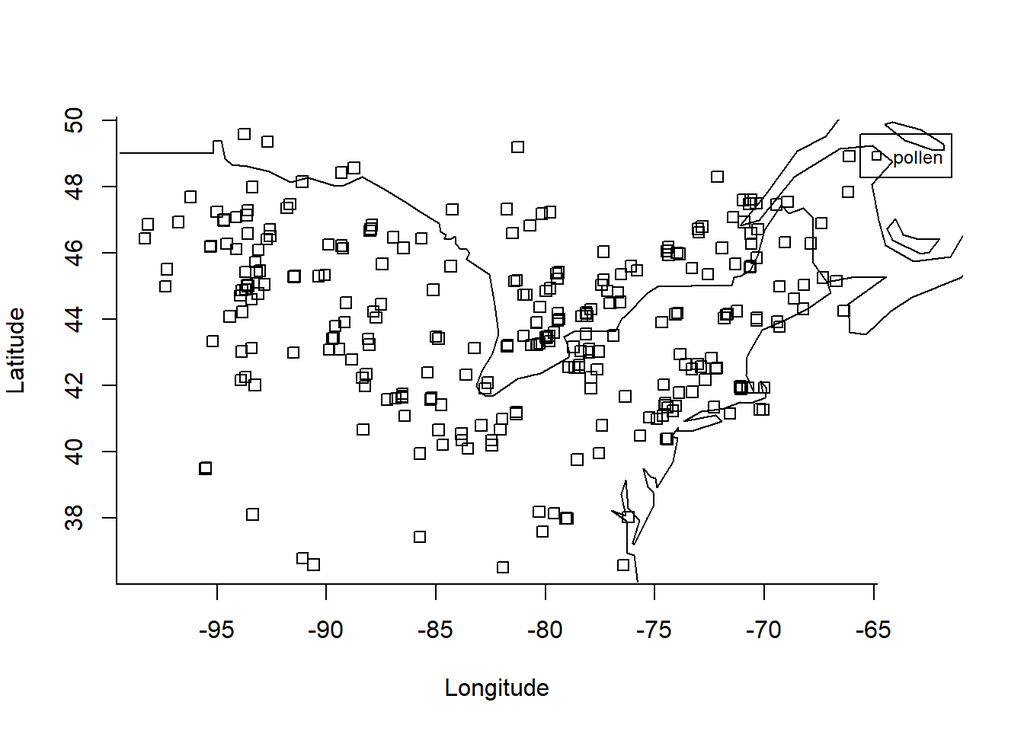

```r
# Making a map of the sites
map <- getMap()
plot(pic.dec)
plot(map, add = TRUE)
```

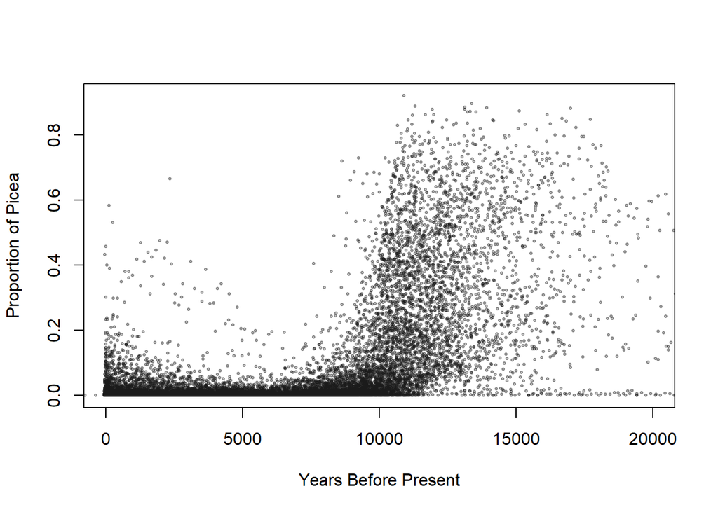

```r
pic.compiled <- compile_downloads(pic.dec.down)

# Extract all taxon tables from the original download object
all.taxa <- do.call(rbind.data.frame, lapply(pic.dec.down, function(x)x$taxon.list[,1:6]))

# Remove duplicate names
all.taxa <- all.taxa[!duplicated(all.taxa),]

# Limit the taxa to everything that is a tree or shrub, or upland herbs

good.cols <- c(1:10, which(colnames(pic.compiled) %in%
      gsub("[ ]|[[:punct:]]", ".",
      all.taxa[all.taxa$ecological.group %in%
      c("TRSH", "UPHE"),1])))

# Take just those trees, shrubs & herbs and transform counts to proportions:
pic.compiled <- pic.compiled[ ,good.cols]
pic.pct <- pic.compiled[,11:ncol(pic.compiled)] / rowSums(pic.compiled[,11:ncol(pic.compiled)], na.rm = TRUE)
pic.only <- rowSums(pic.pct[,grep("Picea", colnames(pic.pct))], na.rm = TRUE)

# Getting chron data and plotting
age.cols <- grep("^age", colnames(pic.compiled))
pic.all <- data.frame(ages = rowMeans(pic.compiled[,age.cols], na.rm = TRUE), prop = pic.only)

# Plot in years before present
plot(pic.all,
     col = rgb(0.1, 0.1, 0.1, 0.3),
     pch = 19, cex = 0.4,
     xlim = c(0, 20000),
     ylab = "Proportion of Picea",
     xlab = "Years Before Present")
```

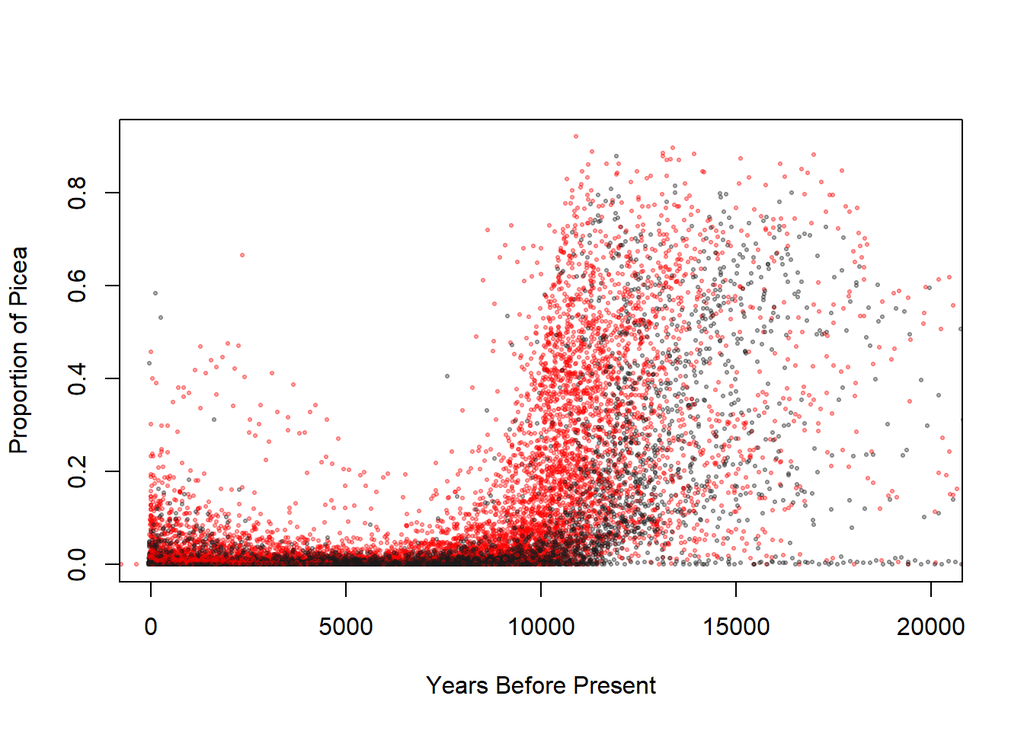

```r
# Plot in radiocarbon years
plot(pic.all,
     col = c(rgb(0.1, 0.1, 0.1, 0.3),
     rgb(1, 0, 0, 0.3))[(pic.compiled$date.type == "Radiocarbon years BP") + 1],
     pch = 19,
     cex = 0.4,
     xlim = c(0, 20000),
     ylab = "Proportion of Picea", xlab = "Years Before Present")
```

#### Question 9

```r
increment <- seq(from = 0, to = 21000, by = 500)
site_nos <- rep(NA, 43)

# Loop to pull data for Picea pollen percentages from 0 to 21ka
for (i in 1:42) {
  one_slice <- get_dataset(taxonname = 'Picea*',
                           datasettype = 'pollen',
                           loc = c(-98.6, 36.5, -66.1, 49.75),
                           ageyoung = increment[i],
                           ageold = increment[i + 1])
  site_nos[i] <- length(one_slice)
}
```

```
## The API call was successful, you have returned 490 records.
```

```
## The API call was successful, you have returned 373 records.
```

```
## The API call was successful, you have returned 342 records.
```

```
## The API call was successful, you have returned 308 records.
```

```
## The API call was successful, you have returned 285 records.
```

```
## The API call was successful, you have returned 270 records.
```

```
## The API call was successful, you have returned 257 records.
```

```
## The API call was successful, you have returned 245 records.
```

```
## The API call was successful, you have returned 238 records.
```

```
## The API call was successful, you have returned 232 records.
```

```
## The API call was successful, you have returned 226 records.
```

```
## The API call was successful, you have returned 235 records.
```

```
## The API call was successful, you have returned 230 records.
```

```
## The API call was successful, you have returned 205 records.
```

```
## The API call was successful, you have returned 233 records.
```

```
## The API call was successful, you have returned 230 records.
```

```
## The API call was successful, you have returned 244 records.
```

```
## The API call was successful, you have returned 217 records.
```

```
## The API call was successful, you have returned 248 records.
```

```
## The API call was successful, you have returned 235 records.
```

```
## The API call was successful, you have returned 263 records.
```

```
## The API call was successful, you have returned 234 records.
```

```
## The API call was successful, you have returned 249 records.
```

```
## The API call was successful, you have returned 206 records.
```

```
## The API call was successful, you have returned 207 records.
```

```
## The API call was successful, you have returned 221 records.
```

```
## The API call was successful, you have returned 182 records.
```

```
## The API call was successful, you have returned 141 records.
```

```
## The API call was successful, you have returned 101 records.
```

```
## The API call was successful, you have returned 88 records.
```

```
## The API call was successful, you have returned 87 records.
```

```
## The API call was successful, you have returned 67 records.
##
## The API call was successful, you have returned 67 records.
```

```
## The API call was successful, you have returned 49 records.
```

```
## The API call was successful, you have returned 38 records.
```

```
## The API call was successful, you have returned 33 records.
```

```
## The API call was successful, you have returned 25 records.
```

```
## The API call was successful, you have returned 37 records.
```

```
## The API call was successful, you have returned 29 records.
```

```
## The API call was successful, you have returned 18 records.
##
## The API call was successful, you have returned 18 records.
```

```
## The API call was successful, you have returned 12 records.
```

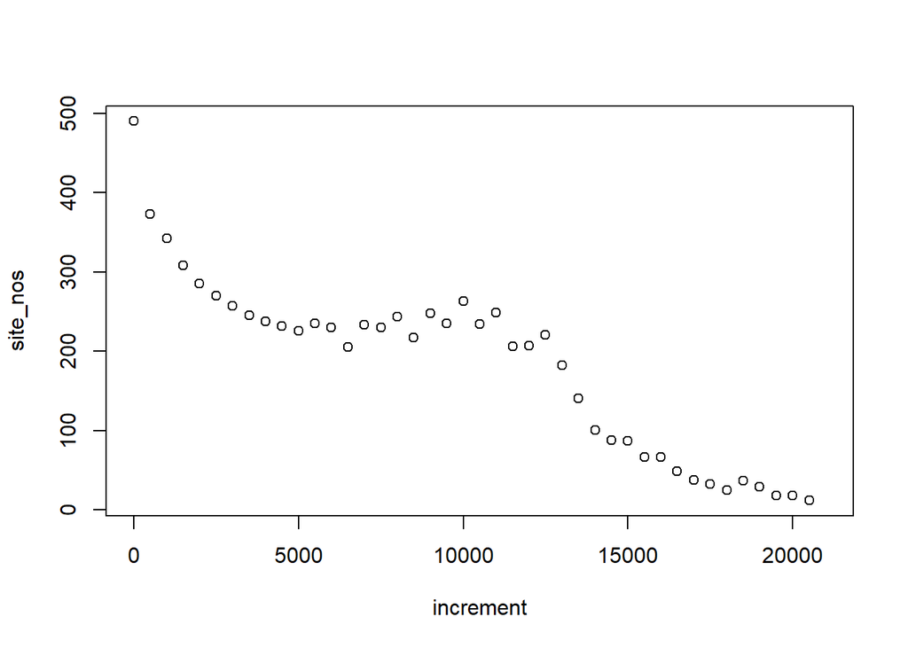

```r
plot(increment, site_nos) # Total counts of sites with Picea in the upper midwest changing over time
```

```r
# Pulling all pollen data for sites in this same region to turn the numbers from the previous loop into proporitons for plotting.
site_all <- rep(NA, 42)
for (i in 1:42) {
  all_slice <- get_dataset(datasettype = 'pollen',
                           loc = c(-98.6, 36.5, -66.1, 49.75),
                           ageyoung = increment[i],
                           ageold = increment[i + 1])
  site_all[i] <- length(all_slice)
}
```

```
## The API call was successful, you have returned 539 records.
```

```
## The API call was successful, you have returned 431 records.
```

```
## The API call was successful, you have returned 388 records.
```

```
## The API call was successful, you have returned 372 records.
```

```
## The API call was successful, you have returned 346 records.
```

```
## The API call was successful, you have returned 331 records.
```

```
## The API call was successful, you have returned 321 records.
```

```
## The API call was successful, you have returned 311 records.
```

```
## The API call was successful, you have returned 295 records.
```

```
## The API call was successful, you have returned 302 records.
```

```
## The API call was successful, you have returned 285 records.
```

```
## The API call was successful, you have returned 299 records.
```

```
## The API call was successful, you have returned 298 records.
```

```
## The API call was successful, you have returned 284 records.
```

```
## The API call was successful, you have returned 300 records.
```

```
## The API call was successful, you have returned 295 records.
```

```
## The API call was successful, you have returned 297 records.
```

```
## The API call was successful, you have returned 261 records.
```

```
## The API call was successful, you have returned 281 records.
```

```
## The API call was successful, you have returned 270 records.
```

```
## The API call was successful, you have returned 277 records.
```

```
## The API call was successful, you have returned 246 records.
```

```
## The API call was successful, you have returned 251 records.
```

```
## The API call was successful, you have returned 210 records.
```

```
## The API call was successful, you have returned 211 records.
```

```
## The API call was successful, you have returned 224 records.
```

```
## The API call was successful, you have returned 182 records.
```

```
## The API call was successful, you have returned 141 records.
```

```
## The API call was successful, you have returned 104 records.
```

```
## The API call was successful, you have returned 88 records.
##
## The API call was successful, you have returned 88 records.
```

```
## The API call was successful, you have returned 67 records.
```

```
## The API call was successful, you have returned 68 records.
```

```
## The API call was successful, you have returned 49 records.
```

```
## The API call was successful, you have returned 40 records.
```

```
## The API call was successful, you have returned 33 records.
```

```
## The API call was successful, you have returned 27 records.
```

```
## The API call was successful, you have returned 38 records.
```

```
## The API call was successful, you have returned 30 records.
```

```
## The API call was successful, you have returned 19 records.
```

```
## The API call was successful, you have returned 18 records.
```

```
## The API call was successful, you have returned 12 records.
```

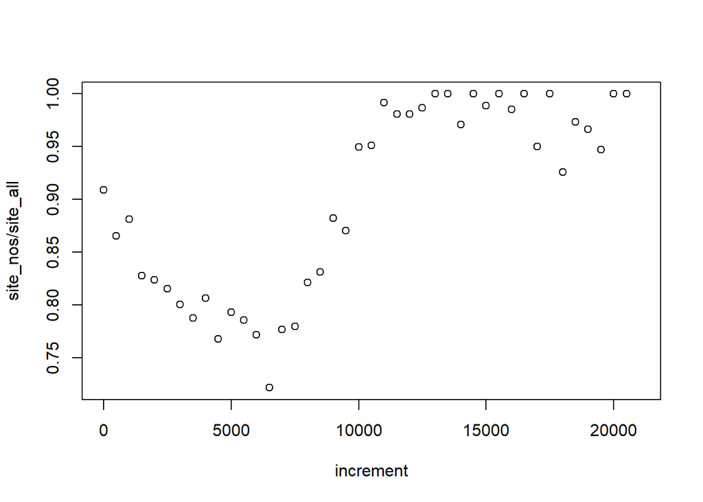

```r
plot(increment, site_nos/site_all) # Proportion of sites with Picea in the upper midwest over time
```